# Practical Part Appplied Biostatistics II

## Part D:

Now, fit a linear model using ridge regression to the cement data set. Use a lambda range of $\lambda \in [0,1]$. Which is the best $\lambda$ value according to the GCV value?

```r
model_ridge <- lm.ridge(y ~ x1 + x2 + x3 + x4, data = cement, lambda = seq(0, 1, by = 0.01))
```

Note: the function lm.ridge automatically standardizes the data; standardizing data should always be done for ridge regression as it makes the shrinking fair to each coefficient. This can be plotted:

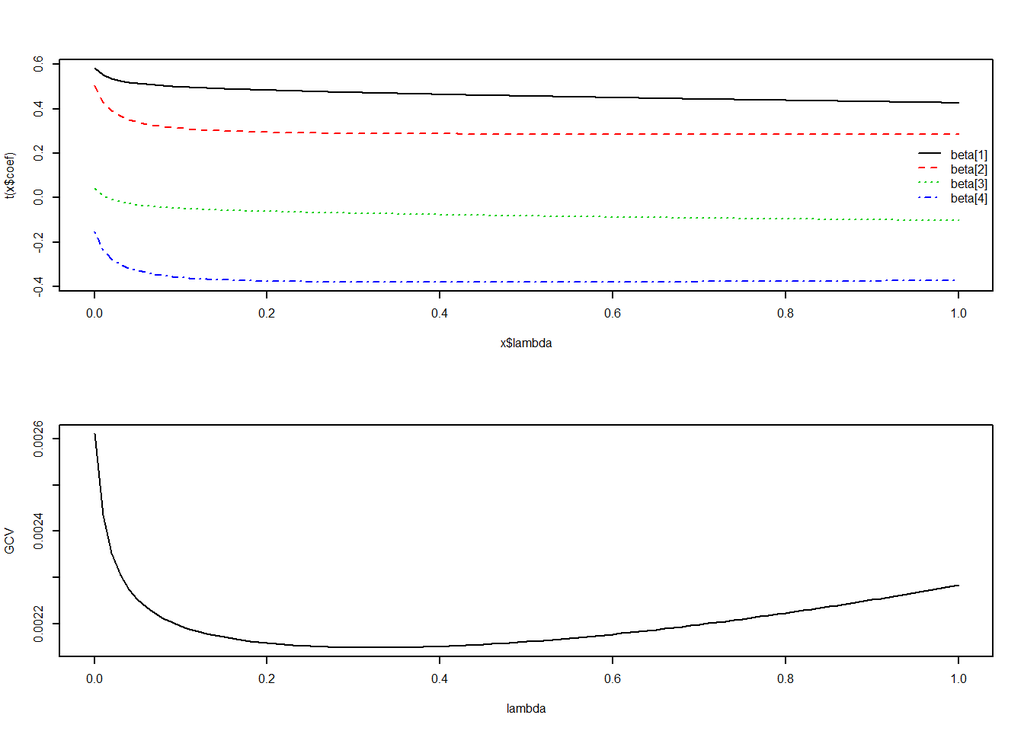

```r
par(mfrow=c(2,1), cex=0.5)
plot(model_ridge)
legend("right",bty="n", col=1:4, lty=1:4, legend=paste("beta[",1:4,"]", sep=""))

plot(model_ridge$lambda, model_ridge$GCV, type="l", xlab="lambda", ylab="GCV")
```

If we look at the ridge trace, the lambda we should pick is one for which the regression coefficients have stabilized (the regression coefficients often vary widely for small $\lambda$ and then stabilize). The smallest $\lambda$ should be chosen as it introduces the smallest bias. Note: increasing $\lambda$ will eventually drive the regression coefficients to zero.

```r
select(model_ridge)
```

```
## modified HKB estimator is 0.08499604
## modified L-W estimator is 0.05830686
## smallest value of GCV  at 0.32
```

The best $\lambda$ is the one with the smallest GCV value. Note: the HKB estimator and the L-W estimator refer to different estimate of the ridge constant $\phi$, i.e. as a rough estimate, you can take $\hat{\beta}_{ridge}=\hat{\phi}\hat{\beta}_{OLS}$), where OLS=ordinary least squares.

## Part E:

Indicate the coefficients of the ridge solution from d) for the determined optimal lambda. As in task b), repeat the ridge fit for the data set without row 3 and 10, respectively, both with the optimal lambda from task d). What do you observe?

```r
model_ridge2 <- lm.ridge(y ~ ., data = cement, lambda = which.min(model_ridge$GCV))
coef.full <- coef(model_ridge2)

model_ridge_w.o.3 <- lm.ridge(y ~ ., data = cement_w.o.3, lambda = which.min(model_ridge$GCV))
coef.w.o.3 <- coef(model_ridge_w.o.3)

model_ridge_w.o.10 <- lm.ridge(y ~ ., data = cement_w.o.10, lambda = which.min(model_ridge$GCV))
coef.w.o.10 <- coef(model_ridge_w.o.10)

ridge <- data.frame(coef.full, coef.w.o.3, coef.w.o.10)
ridge
```

```
##        coef.full  coef.w.o.3 coef.w.o.10
##     1.927723e-16 -0.02156153 -0.07069794
## x1  1.588718e-01  0.15193007  0.16858567
## x2  1.684314e-01  0.16098364  0.16432162
## x3 -1.060207e-01 -0.10053798 -0.08131035
## x4 -1.738900e-01 -0.16672916 -0.16043173
```

-> The coefficients for x<sub>1</sub> to x<sub>4</sub> are very similar in all three models, i.e. we solved our problem of unstable predictions due to collinearity!